# Titers for a serum

# Titers for a serum

Analyze titers for a serum, aggregating replicates which may be across multiple plates.

```python
import pickle

import altair as alt

import neutcurve

import pandas as pd

_ = alt.data_transformers.disable_max_rows()
```

Get variables from `snakemake`:

```python
plate_fits = snakemake.input.plate_fits
pickle_fits = snakemake.input.pickles
viral_strain_plot_order = snakemake.params.viral_strain_plot_order
per_rep_titers_csv = snakemake.output.per_rep_titers
median_titers_csv = snakemake.output.median_titers
curves_pdf = snakemake.output.curves_pdf
output_pickle = snakemake.output.pickle
serum = snakemake.wildcards.serum
qc_thresholds = snakemake.params.qc_thresholds
qc_exclusions = snakemake.params.qc_exclusions
qc_failures_file = snakemake.output.qc_failures
```

Process the QC exclusions:

```python
print(f"The QC thresholds are:\n{qc_thresholds}")

# get viruses for which we are ignoring QC
viruses_ignore_qc = [
    virus
    for virus, d in qc_exclusions.items()
    if "ignore_qc" in d and d["ignore_qc"] is True
]
if viruses_ignore_qc:
    print("\nIgnoring QC for these viruses:\n\t" + "\n\t".join(viruses_ignore_qc))

# get virus replicates to drop
virus_replicates_to_drop = [
    (virus, rep)
    for virus, d in qc_exclusions.items()
    for rep in (d["replicates_to_drop"] if "replicates_to_drop" in d else [])
]
if virus_replicates_to_drop:
    print(
        "\nDropping these virus-replicates:\n\t"
        + "\n\t".join(str(tup) for tup in virus_replicates_to_drop)
    )
```

```
The QC thresholds are:
{'min_frac_infectivity': 0.7, 'min_replicates': 2, 'max_fold_change_from_median': 3}

Ignoring QC for these viruses:
	A/Bangladesh/8036/2021
	A/Brisbane/48/2022
	A/India-PUN-NIV328484/2021
	A/Perth/1/2022
	A/Washington/23/2020
```

Read all titers for this serum, dropping virus/replicates to drop:

```python
print(f"Reading titers for {serum=}")

assert len(plate_fits)

serum_fits = pd.concat([pd.read_csv(f) for f in plate_fits]).query("serum == @serum")

# remove virus-replicates to drop
print(f"Read a total of {len(serum_fits)} titers")
assert "tup" not in set(serum_fits.columns)
serum_fits = (
    serum_fits.assign(
        tup=lambda x: list(
            x[["virus", "replicate"]].itertuples(index=False, name=None)
        ),
    )
    .query("tup not in @virus_replicates_to_drop")
    .drop(columns="tup")
)
print(f"Retained {len(serum_fits)} titers after dropping specified ones")

assert len(serum_fits), f"no titers for {serum=}"
assert len(serum_fits) == len(serum_fits.groupby(["replicate", "virus"]))
print(f"Read a total of {len(serum_fits)} titers for {serum=}")

# get viruses in the order to plot them
viruses = sorted(serum_fits["virus"].unique())
if viral_strain_plot_order is not None:
    if not set(viruses).issubset(viral_strain_plot_order):
        raise ValueError(
            "`viral_strain_plot_order` lacks some viruses with titers:\n"
            + str(set(viruses) - set(viral_strain_plot_order))
        )
    viruses = [v for v in viral_strain_plot_order if v in viruses]
print(f"{serum=} has titers for a total of {len(viruses)} viruses")
```

```
Reading titers for serum='Y044d30'
Read a total of 110 titers
Retained 110 titers after dropping specified ones
Read a total of 110 titers for serum='Y044d30'
serum='Y044d30' has titers for a total of 36 viruses
```

Get the NT50s per replicate. Note that a lower bound in the IC50s represents and upper-bound on the NT50s:

```python
per_rep_titers = serum_fits.assign(
    nt50=lambda x: 1 / x["ic50"],
    nt50_bound=lambda x: x["ic50_bound"].map(
        {"interpolated": "interpolated", "upper": "lower", "lower": "upper"}
    ),
)[["serum", "replicate", "virus", "nt50", "nt50_bound"]]

assert per_rep_titers.notnull().all().all()

print(f"Saving {len(per_rep_titers)} per-replicate titers to {per_rep_titers_csv}")
per_rep_titers.to_csv(per_rep_titers_csv, index=False, float_format="%.4g")
```

```
Saving 110 per-replicate titers to results/sera/Y044d30/titers_per_replicate.csv
```

Get the median titers and the standard error of the mean. We defined the bounds (is the measurement interpolated or at a bound of the dilution series) for the median as the same as the bounds for the median measurement if there are an odd number of measurements, or if there are an even number of measurements interpolated only if all of the middle values are interpolated:

```python
def get_median_nt50_bound(s):
    """Get the bound for the median NT50."""
    s = list(s)
    if len(s) % 2:
        return s[len(s) // 2]
    else:
        bounds = s[len(s) // 2 - 1 : len(s) // 2 + 1]
        assert len(bounds) == 2
        if len(set(bounds)) == 1:
            return bounds[0]
        elif "interpolated" in bounds:
            return [b for b in bounds if b != "interpolated"][0]
        else:
            return "inconsistent"


median_titers = (
    per_rep_titers.sort_values("nt50")  # for getting median nt50 bound
    .groupby(["serum", "virus"], as_index=False)
    .aggregate(
        nt50=pd.NamedAgg("nt50", "median"),
        n_replicates=pd.NamedAgg("replicate", "count"),
        nt50_stderr=pd.NamedAgg("nt50", "sem"),
        nt50_bound=pd.NamedAgg("nt50_bound", get_median_nt50_bound),
    )
)

print(f"Saving {len(median_titers)} median titers to {median_titers_csv}")
median_titers.to_csv(median_titers_csv, index=False, float_format="%.4g")
```

```
Saving 36 median titers to results/sera/Y044d30/titers_median.csv
```

Plot the per-replicate and median titers:

```python
virus_selection = alt.selection_point(fields=["virus"], on="mouseover", empty=False)

per_rep_chart = (
    alt.Chart(per_rep_titers)
    .encode(
        alt.X(
            "nt50",
            title="neutralization titer",
            scale=alt.Scale(nice=False, padding=5, type="log"),
        ),
        alt.Y("virus", sort=viruses),
        alt.Shape("nt50_bound", title="is titer bound?"),
        strokeWidth=alt.condition(virus_selection, alt.value(2), alt.value(0)),
        tooltip=[
            alt.Tooltip(c, format=".3g") if per_rep_titers[c].dtype == float else c
            for c in per_rep_titers
            if c != "serum"
        ],
    )
    .mark_point(
        size=45,
        filled=True,
        fillOpacity=0.5,
        strokeOpacity=1,
        stroke="black",
        color="#56B4E9",
    )
)

median_chart = (
    alt.Chart(median_titers)
    .encode(
        alt.X(
            "nt50",
            title="neutralization titer",
            scale=alt.Scale(nice=False, padding=5, type="log"),
        ),
        alt.Y("virus", sort=viruses),
        alt.Shape("nt50_bound", title="is titer bound?"),
        strokeWidth=alt.condition(virus_selection, alt.value(2), alt.value(0)),
        tooltip=[
            alt.Tooltip(c, format=".3g") if median_titers[c].dtype == float else c
            for c in median_titers
            if c != "serum"
        ],
    )
    .mark_point(
        color="#E69F00",
        size=85,
        filled=True,
        fillOpacity=0.9,
        strokeOpacity=1,
        stroke="black",
    )
)

titer_chart = (
    (per_rep_chart + median_chart)
    .add_params(virus_selection)
    .properties(
        height=alt.Step(14),
        width=250,
        title=f"{serum} median (orange) and per-replicate (blue) titers",
    )
    .configure_axis(grid=False)
)

titer_chart
```

[interactive chart not shown]

Combine all the `CurveFits` for this serum and retained viruses:

```python
fits_to_combine = []
for fname in pickle_fits:
    with open(fname, "rb") as f:
        fits_to_combine.append(pickle.load(f))
serum_curvefits = neutcurve.CurveFits.combineCurveFits(
    fits_to_combine,
    sera=[serum],
    serum_virus_replicates_to_drop=[
        (serum, virus, replicate) for (virus, replicate) in virus_replicates_to_drop
    ],
)
```

Get any QC failures (ignoring any viruses for which we specified to ignore QC), and write to file:

```python
qc_failures = []

insufficient_replicates = (
    median_titers.sort_values("virus", key=lambda s: s.map(lambda v: viruses.index(v)))
    .reset_index(drop=True)[
        median_titers["n_replicates"] < qc_thresholds["min_replicates"]
    ]
    .query("virus not in @viruses_ignore_qc")
    .drop(columns="serum")
)
if len(insufficient_replicates):
    print(f"The following viruses fail {qc_thresholds['min_replicates']=}")
    display(insufficient_replicates)
    qc_failures.append("min_replicates")
else:
    print(f"All viruses pass {qc_thresholds['min_replicates']=}")

max_fold_change_from_median = qc_thresholds["max_fold_change_from_median"]
assert max_fold_change_from_median > 1, max_fold_change_from_median
excess_fold_change_from_median = (
    median_titers.rename(columns={"nt50": "median_nt50"})[["virus", "median_nt50"]]
    .merge(per_rep_titers, validate="one_to_many")
    .assign(
        fold_change_from_median=lambda x: x["nt50"] / x["median_nt50"],
        excess_fold_change=lambda x: (
            (x["fold_change_from_median"] > max_fold_change_from_median)
            | (x["fold_change_from_median"] < 1 / max_fold_change_from_median)
        ),
    )
    .sort_values("virus", key=lambda s: s.map(lambda v: viruses.index(v)))
    .reset_index(drop=True)
    .query("excess_fold_change and (virus not in @viruses_ignore_qc)")[
        ["virus", "replicate", "median_nt50", "nt50", "fold_change_from_median"]
    ]
)
if len(excess_fold_change_from_median):
    print(f"\nThese replicates fail {qc_thresholds['max_fold_change_from_median']=}")
    display(excess_fold_change_from_median)
    qc_failures.append("max_fold_change_from_median")
else:
    print(f"\nAll viruses pass {qc_thresholds['max_fold_change_from_median']=}")

qc_failures = "\n".join(qc_failures)
if qc_failures:
    print(f"\nEncountered the following QC failures:\n{qc_failures}")
else:
    print("\nNo QC failures")
print(f"\nLogging QC failures to {qc_failures_file}")
with open(qc_failures_file, "w") as f:
    f.write(qc_failures)
```

```
All viruses pass qc_thresholds['min_replicates']=2

These replicates fail qc_thresholds['max_fold_change_from_median']=3
```

|  | virus | replicate | median_nt50 | nt50 | fold_change_from_median |
| --- | --- | --- | --- | --- | --- |
| 29 | A/Hawaii/70/2019 | plate11-AGTAAACATGCATTGG | 15342.093254 | 4987.531172 | 0.325088 |
| 86 | A/Chester/5355/2022 | plate11-TCATATAAAGAAAAGG | 900.900901 | 4306.632214 | 4.780362 |

```
Encountered the following QC failures:
max_fold_change_from_median

Logging QC failures to results/sera/Y044d30/qc_failures.txt
```

Plot the individual neutralization curves:

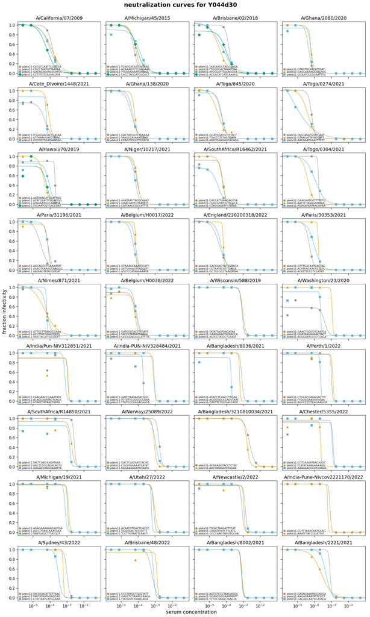

```python
fig, _ = serum_curvefits.plotReplicates(
    attempt_shared_legend=False,
    legendfontsize=8,
    ncol=4,
    heightscale=1.25,
    widthscale=1.25,
    viruses=viruses,
    subplot_titles="{virus}",
)

_ = fig.suptitle(
    f"neutralization curves for {serum}", y=1, fontsize=18, fontweight="bold"
)

fig.tight_layout()
```

Save the curves to a file:

```python
print(f"Saving to {curves_pdf}")
fig.savefig(curves_pdf)
```

```
Saving to results/sera/Y044d30/curves.pdf
```

Save the `CurveFits` for the serum to a pickle file:

```python
with open(output_pickle, "wb") as f:
    pickle.dump(serum_curvefits, f)
```